# Analysis of the Spoilt Votes in Kenya’s 2013 Presidential Elections

Herman Githinji Mwangi

2023-11-04

https://rpubs.com/jojherman/

https://github.com/jojherman/

githinjiherman@gmail.com

# Abstract

This study explores factors influencing spoilt votes in Kenyan constituencies during the 2013 presidential elections. The total number of spoilt votes were 108,700. It addresses a knowledge gap of how registered voters 14,292,665, cast votes 12,277,194, voting patterns’Landslide’ or ‘Close Race’ influence the number of spoilt votes as well as the implications of the spoilt votes on constituency development fund (CDF) allocation KES: 138 Billion. This data represents 289 out of the total 291 constituencies. The primary goal is to unveil these factors’ impact on spoilt vote numbers, the effect of spoilt votes on CDF allocation, with broader implications for election integrity and policy in Kenya. The study employs quantitative analysis, focusing on linear regression, to provide empirical evidence. In conclusion, it contributes vital insights to election dynamics and the Kenyan electoral landscape.

# Introduction

This study aims to contribute to a better understanding of the Kenyan electoral landscape and provide data-driven recommendations for policymakers to bolster the integrity of future elections in the country. The analysis of the factors influencing spoilt votes offers insights into the underlying dynamics of voter behavior and the electoral process.

These factors play a crucial role in shaping the electoral landscape, as they can impact the overall integrity of the election process. Additionally, the study explains the reciprocal relationship between spoilt votes and the allocation of Constituency Development Funds (CDF), exploring how this allocation is affected by the number of spoilt votes. The study’s findings have broader implications for election integrity and policy in Kenya.

To achieve these objectives, this study adopts a quantitative approach, employing the tools of statistical analysis, particularly focusing on linear regression. By utilizing quantitative methods, the research aims to provide empirical evidence that can help policymakers, election authorities, and stakeholders make informed decisions and implement measures to enhance the fairness and credibility of future elections in Kenya.

# Background to the study

In the 2013 Kenyan presidential election, Uhuru Kenyatta emerged as the winner with 50.07 percent of the vote, securing a first-round victory. Notably, the election witnessed an exceptionally high voter turnout, with 85.86 percent of registered voters actively participating. Out of a total of 12,330,028 votes cast, 108,975 were deemed invalid, resulting in a spoilt vote percentage of roughly 0.88 percent. These statistics reveal only 33.34 percent of the total population registered as voters, underscoring the significance and democratic vitality of this pivotal election.

# Study objectives

How do variables like the number of registered voters, cast votes, and voting patterns affect the number of spoilt votes? Is there a significant correlation between the allocation of CDF funds and the occurrence of spoilt votes? What policy recommendations can be derived from these findings to improve election integrity and voter participation in Kenya?

## Key Election Information Summary

| Variable | Value |
| --- | --- |
| Cast Votes | 12,330,028 |
| Valid Votes | 12,221,053 |
| Invalid Votes | 108,975 |
| Registered Voters | 14,352,533 |
| Population (July 2012 est.) | 43,013,341 |
| Voter Turnout | 85.86% |
| Spoilt Vote Percentage | 0.88% |
| Registered Voter Percentage | 33.34% |
| CLOSE RACE | 55 constituencies |
| LANDSLIDE | 234 constituencies |
| CDF Allocation (2013-2017) | KES 138 billion |

Summary of Minimum, Median, Mean, Maximum values of Spoilt, Registered, Cast, and Allocation variables respectively.

| Variable | Min | Median | Mean | Max |
| --- | --- | --- | --- | --- |
| Spoilt | 0 | 344 | 3.761246e+02 | 1253 |
| Registered | 10574 | 44489 | 4.945559e+04 | 133279 |
| Cast | 8718 | 37917 | 4.248164e+04 | 110828 |
| Allocation | 415636890 | 474971364 | 4.801269e+08 | 682170481 |

# Density Plot

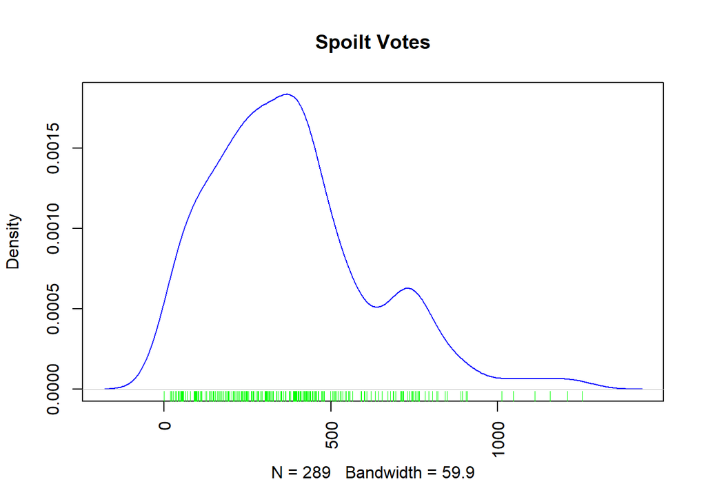

# Histograms

Histograms are a graphical representation commonly used to display the distribution of a data variable and its corresponding frequency or count of observations within different intervals. Histograms are valuable for exploring and summarizing data, identifying central tendencies (such as modes and medians), detecting outliers, and assessing the spread or variation of the data as shown

# Spoilt votes

The histogram in the next slide represents the distribution of the Spoilt Votes in the dataset. The x-axis ranges from 0 to 1200, divided into intervals of 100, and represents the Spoilt votes. The y-axis ranges from 0 to 60, divided into intervals of 10, and represents the frequency of these values.

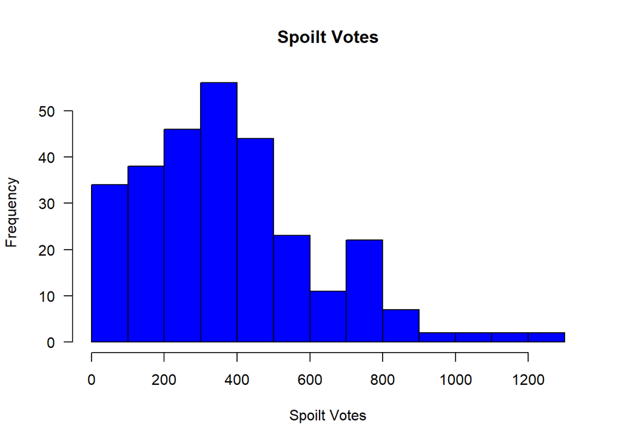

From the histogram, we can observe that: The majority of the Spoilt Votes fall within the range of 300 to 400. The percentage of Spoilt Votes that fall within the 300-400 range is approximately 19.378 percent of the total Spoilt votes}. The frequency count for Spoilt Votes falling within the range of 300 to 400 is 56. This means there are 56 instances in the dataset where the Spoilt votes are between 300 and 400. The skewness of the Spoilt Votes is approximately 0.90.

This value indicates a moderate positive skew, which means the distribution of Spoilt votes is skewed to the right.

# CDF Allocation

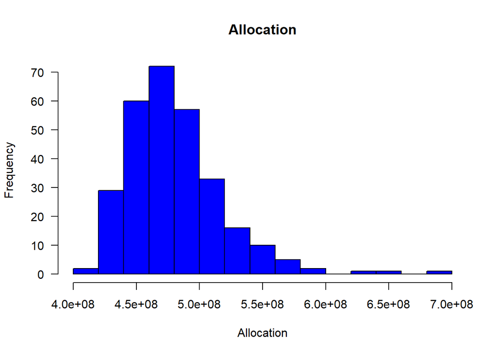

# Cast votes

The histogram in the next slide represents the distribution of the Cast votes in the dataset. The x-axis ranges from 0 to 120,000, divided into intervals of 10,000, and represents the Cast votes. The y-axis ranges from 0 to the maximum frequency count 84

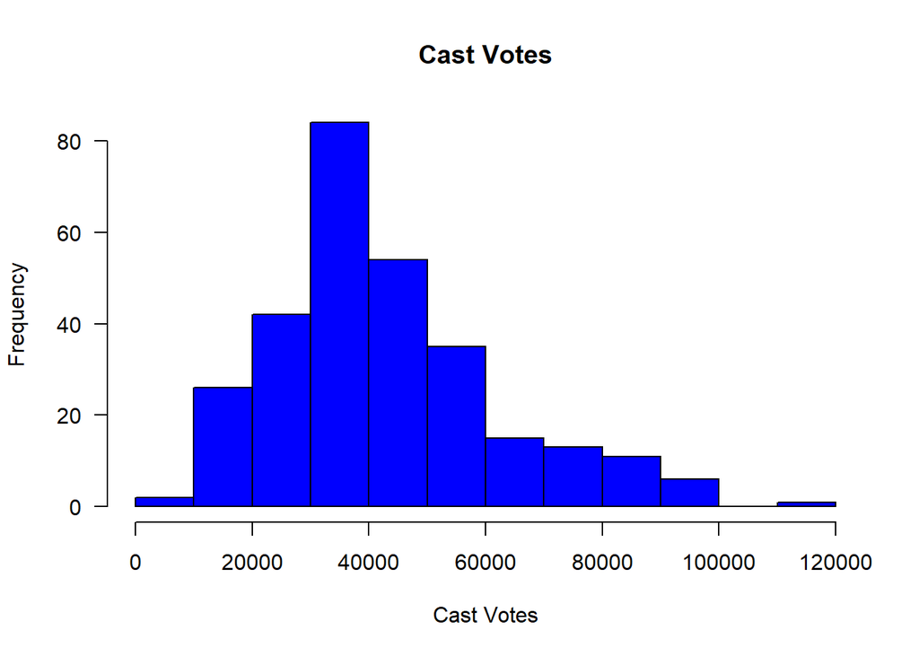

From the histogram, we can observe that:

The majority of the Cast votes fall within the range of 30,000 to 40,000. The percentage of Cast votes that fall within the 30,000 to 40,000 range is approximately 29.07 percent of the total Cast votes. The frequency count for Cast votes falling within the range of 30,000 to 40,000 is 84. This means there are 84 instances in the dataset where the Cast votes are between 30,000 and 40,000. The skewness of the Cast votes is approximately 0.84.

This value indicates a moderate positive skew, which means the distribution of Cast votes is skewed to the right.

The histogram in the next slide represents the distribution of the Registered voters in the dataset. The x-axis ranges from 0 to 140,000, divided into intervals of 10,000, and represents the Registered voters. The y-axis ranges from 0 to the maximum frequency count 66

# Registered voters

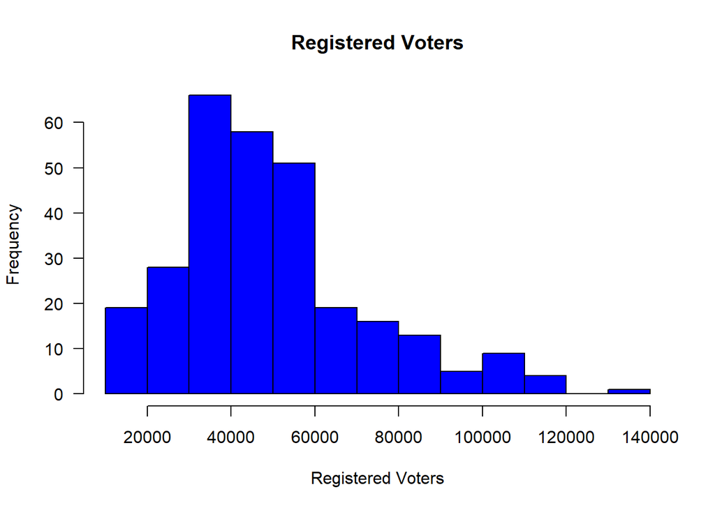

From the histogram,

The majority of the Registered voters fall within the range of 30,000 to 40,000. The percentage of Registered voters that fall within the 30,000 to 40,000 range is approximately 22.84 percent of the total Registered voters. The frequency count for Registered voters falling within the range of 30,000 to 40,000 is 66. This means there are 66 instances in the dataset where the Registered voters are between 30,000 and 40,000. The skewness of the Registered voters is approximately 0.96.

This value indicates a moderate positive skew, which means the distribution of Registered voters is skewed to the right

# Voting Pattern

The data shows two distinct voting patterns:

CLOSE RACE: Elections were fiercely competitive, with a narrow margin of victory. Outcomes were uncertain. LANDSLIDE: one choice dominated, securing a decisive and one-sided victory.

# Pie Chart

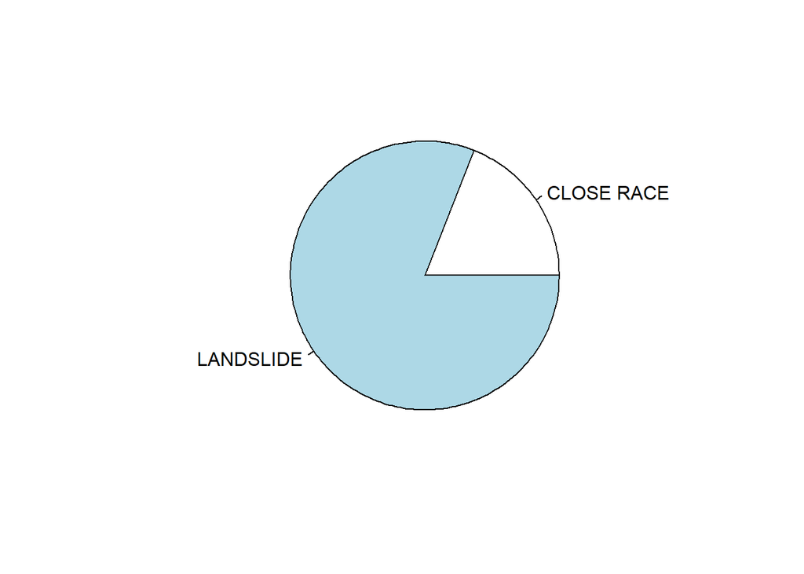

# Bar Plot

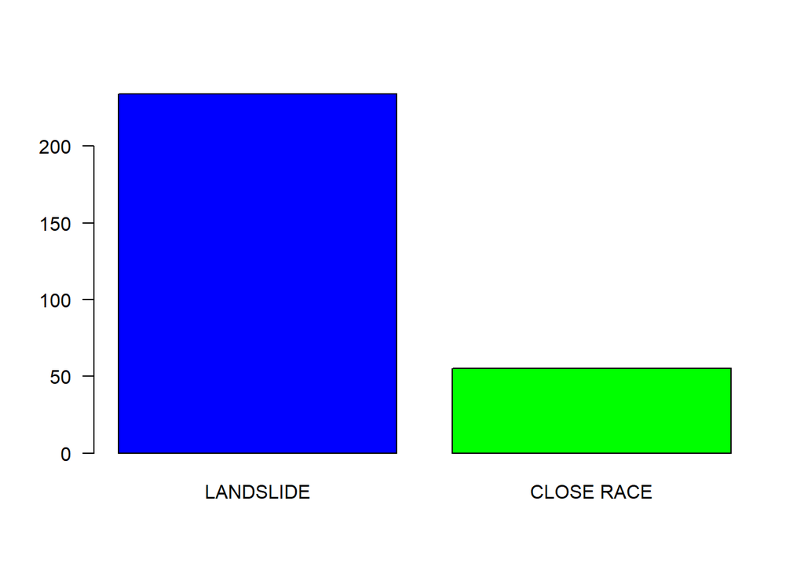

# Pattern Count

Voting pattern counts for “CLOSE RACE” and “LANDSLIDE”

| Pattern | Count |
| --- | --- |
| CLOSE RACE | 55 |
| LANDSLIDE | 234 |

# More on Pattern Variable

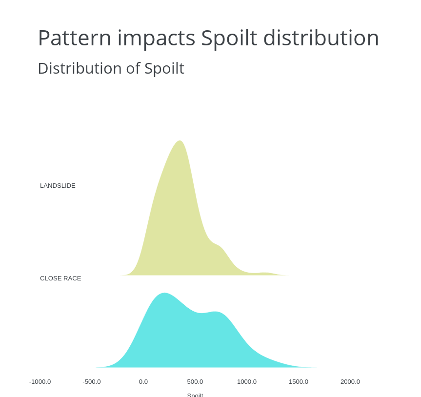

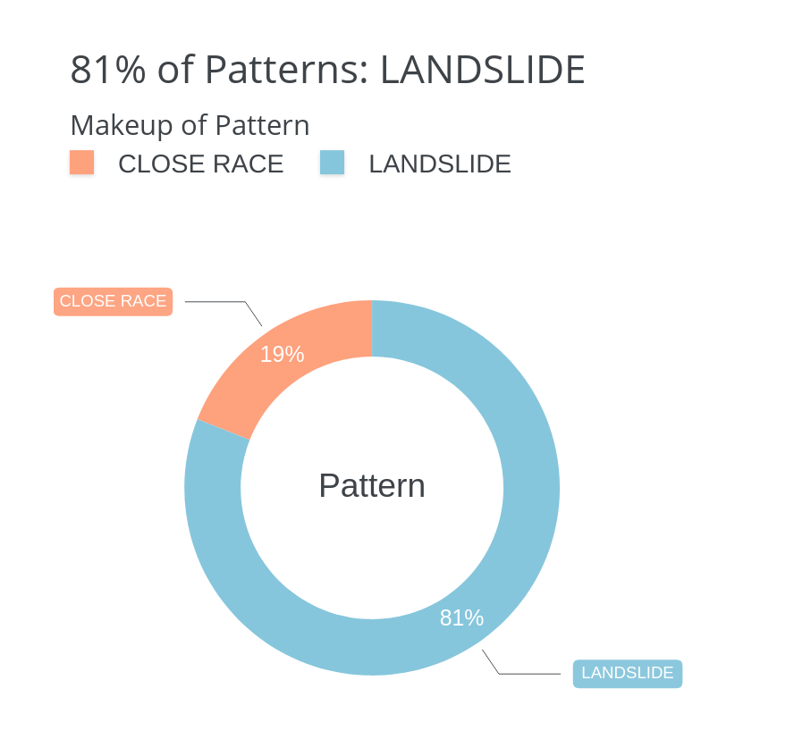

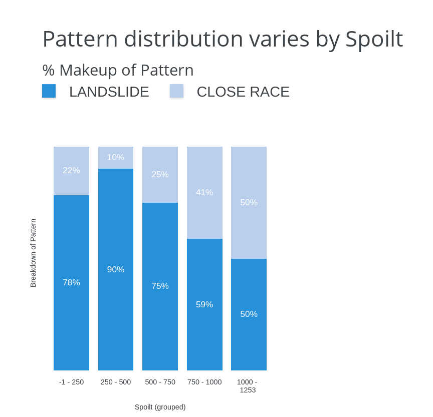

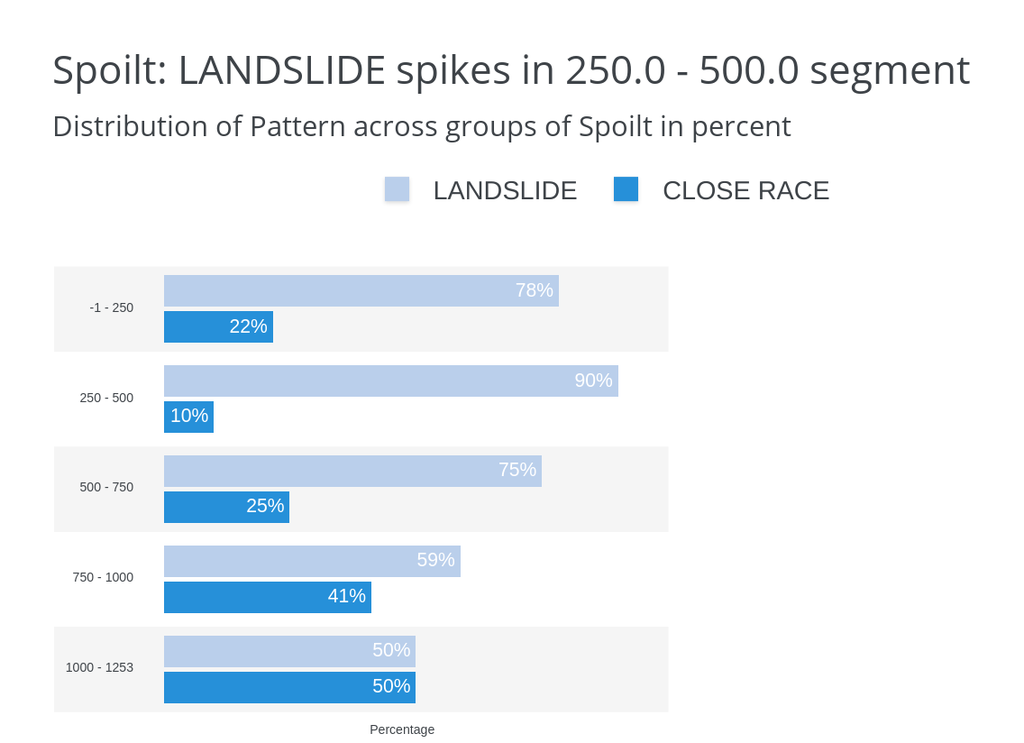

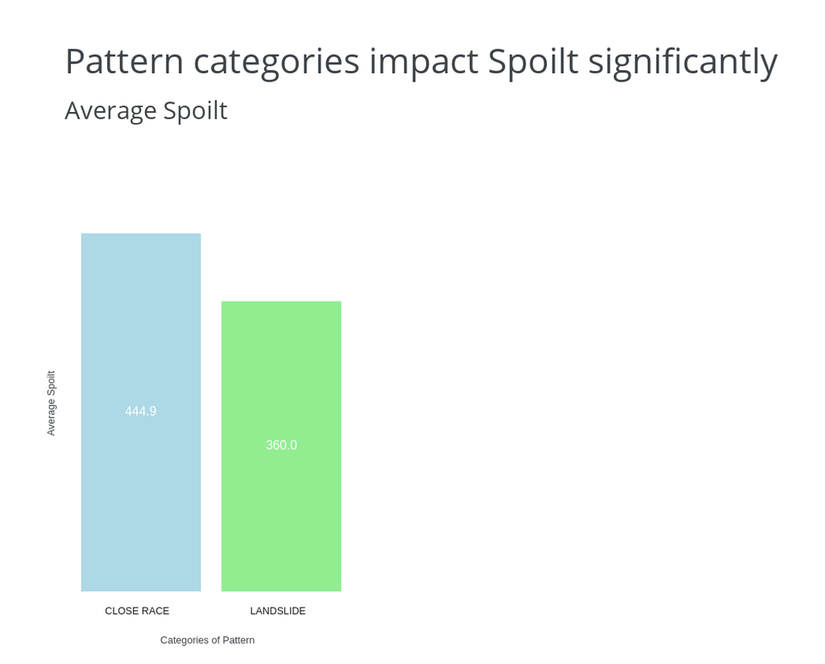

# Box Plot

The box plot in the next slide shows the distribution of the number of spoiled votes in each category of election result pattern. The line in the middle of each box represents the median of the data, while the box itself represents the interquartile range (from the first quartile to the third quartile). The whiskers represent the range of the data within 1.5 times the interquartile range, and any points outside of this range are considered outliers and are represented as individual points. From this plot, we can see that the distribution of spoiled votes varies between different election result patterns.

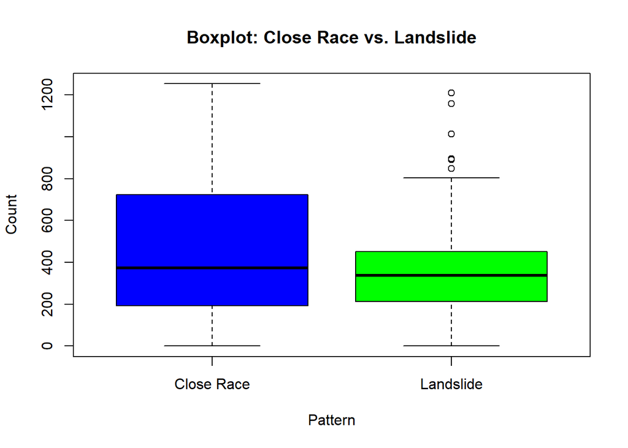

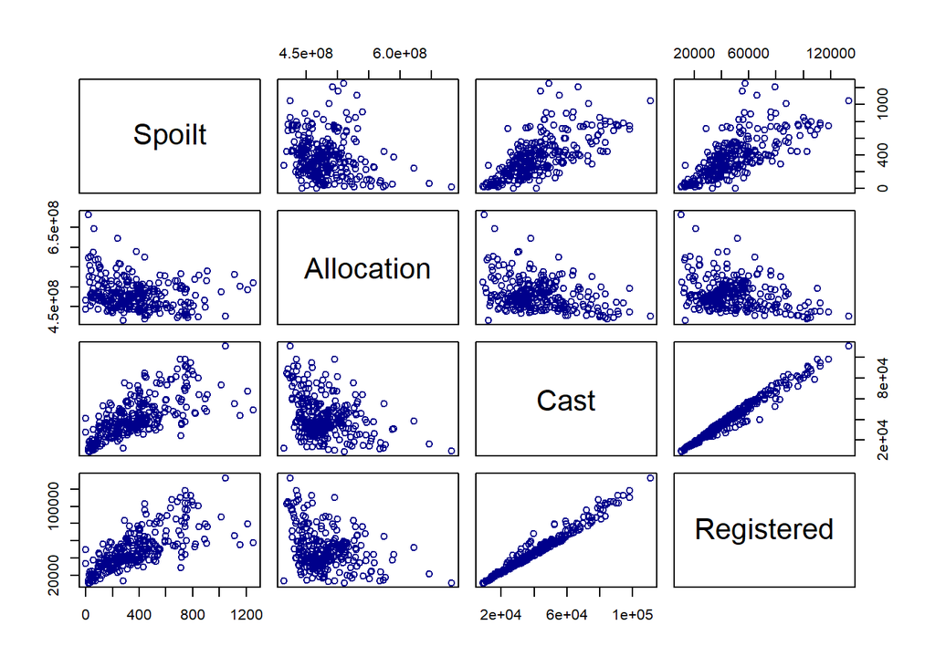

## Correlation Coefficients

As shown in the scatter plots, some variables are related directionally either positively or negatively. The correlation coefficients indicate the strength and direction of these relationships. Positive values suggest a direct (positive) relationship, where both variables tend to move in the same direction. Negative values indicate an inverse (negative) relationship, where the variables tend to move in opposite directions. The closer the correlation coefficient is to -1 or 1, the stronger the relationship.

# Matrix

|  | Spoilt | Registered | Cast | Allocation |
| --- | --- | --- | --- | --- |
| Spoilt | 1.0000 | 0.7168 | 0.6795 | -0.2077 |
| Registered | 0.7168 | 1.0000 | 0.9808 | -0.3251 |
| Cast | 0.6795 | 0.9808 | 1.0000 | -0.3431 |
| Allocation | -0.2077 | -0.3251 | -0.3431 | 1.0000 |

# Correlation Coefficients Analysis

Spoilt vs. Registered: There is a moderately positive relationship (correlation coefficient of 0.7168) between Spoilt and Registered. As the number of Registered voters increases, the number of Spoilt votes tends to increase, indicating that higher voter registration may lead to more Spoilt votes. Spoilt vs. Cast: Similar to the relationship with Registered, there is also a moderately positive relationship (correlation coefficient of 0.6795) between Spoilt and Cast. This suggests that as the number of votes Cast increases, the number of Spoilt votes tends to increase as well.

Spoilt vs. Allocation: There is a weak negative relationship (correlation coefficient of -0.2077) between Spoilt and Allocation. As Allocation increases, the number of Spoilt votes tends to decrease slightly, indicating a slight inverse relationship. Registered vs. Cast: There is a very strong positive relationship (correlation coefficient of 0.9808) between Registered and Cast. This means that as the number of Registered voters increases, the number of votes Cast also significantly increases.

Registered vs. Allocation: There is a moderately negative relationship (correlation coefficient of -0.3251) between Registered and Allocation. As Allocation increases, the number of Registered voters tends to decrease. Cast vs. Allocation: There is also a moderately negative relationship (correlation coefficient of -0.3431) between Cast and Allocation. As Allocation increases, the number of votes Cast tends to decrease.

# Linear Regression

The lm function provides a comprehensive analysis of the relationship between the response variable, ‘Spoilt votes’ (Y), and the predictor variables: ‘Registered Voters’ (X1), ‘Cast Votes’ (X2), ‘Voting Patterns’ (X3), and ‘CDF Allocation’ (X4).

## Variable Descriptions

| Variable | Description |
| --- | --- |
| $Y$ | Represents Spoilt votes (invalid) |
| $X_1$ | Represents Registered Voters |
| $X_2$ | Represents Cast votes |
| $X_3$ | Represents Voting Patterns per constituency (Close race or landslide) |
| $X_4$ | Represents Allocation of CDF Funds per constituency |

$$Y = \beta_0 + \beta_1 X_1 + \beta_2 X_2 + \beta_3 X_3 + \beta_4 X_4 +
\epsilon$$

Where

Y: Response variable (Spoilt votes) X1: Number of registered voters X2: Number of cast votes X3: Voting patterns per constituency (Close race or landslide) X4: Allocation of CDF Funds per constituency

$\beta_0, \beta_1, \beta_2, \beta_3, \beta_4, and, \epsilon$

represent coefficients of respective explanatory variables on the response variable, and $\epsilon$ represents the error term.

# Hypothesis Testing

The hypothesis testing will help us determine whether any of the predictor variables have a statistically significant impact on the number of Spoilt votes in the linear regression model.

Null Hypothesis (H0). There is no significant relationship between the number of Spoilt votes and the predictor variables, including the number of Registered Voters, Cast Votes, Voting Patterns, and CDF Allocation. In mathematical terms, this can be expressed as H0: $\beta_0 = \beta_1 = \beta_2 = \beta_3 = \beta_4$ = 0. Alternate Hypothesis (H1). There is a significant relationship between the number of Spoilt votes and at least one of the predictor variables, including the number of Registered Voters, Cast Votes, Voting Patterns, and CDF Allocation. In mathematical terms, this can be expressed as H1: At least one of $\beta_0, \beta_1, \beta_2, \beta_3, \beta_4$ is not 0.

```
##
## ===============================================
##                         Dependent variable:
##                     ---------------------------
##                                  Y
## -----------------------------------------------
## X1                       0.013*** (0.002)
## X2                       -0.007** (0.003)
## X3LANDSLIDE             -64.158** (24.834)
## X4                       0.00000 (0.00000)
## Constant                 13.808 (140.393)
## -----------------------------------------------
## Observations                    289
## R2                             0.539
## Adjusted R2                    0.533
## Residual Std. Error     163.304 (df = 284)
## F Statistic           83.178*** (df = 4; 284)
## ===============================================
## Note:               *p<0.1; **p<0.05; ***p<0.01
```

# Lower and Upper Confidence Intervals

Confidence intervals for the linear regression model, Lower CI:2.5 vs Upper CI 97.5 percent

| Variable | Lower CI | Upper CI |
| --- | --- | --- |
| (Intercept) | -2.625348e+02 | 2.901504e+02 |
| X1 | 8.645493e-03 | 1.738032e-02 |
| X2 | -1.168361e-02 | -1.323314e-03 |
| X3LANDSLIDE | -1.130398e+02 | -1.527593e+01 |
| X4 | -4.348301e-07 | 6.305344e-07 |

# Causal Effects Analysis

Number of Registered Voters (X1): An increase in the number of registered voters (with each additional unit) leads to an increase in Spoilt votes. For every one-unit increase in the number of registered voters, Spoilt votes are expected to increase by approximately 0.0130 units, which is a positive effect. The p-value for the effect of the number of registered voters on Spoilt votes is less than 0.05, indicating high statistical significance.

Number of Cast Votes (X2): An increase in the number of cast votes (with each additional unit) leads to a decrease in Spoilt votes. For every one-unit increase in the number of cast votes, Spoilt votes are expected to decrease by approximately 0.0065 units, indicating a negative effect. The p-value for the effect of the number of cast votes on Spoilt votes is less than 0.05, indicating statistical significance.

Landslide Pattern (X3): The coefficient for Voting Patterns landslide is -64.1579, which means the presence of a landslide voting pattern is associated with a decrease in Spoilt votes by 64.1579 units. The p-value for Voting Patterns landslide is 0.010, which is less than 0.05. This suggests that Voting Patterns landslide is a statistically significant predictor of Spoilt votes.

Allocation (X4): The coefficient for CDF Allocation is 9.785e-08, which means for every one-unit increase in CDF Allocation, the Spoilt votes are expected to increase by 9.785e-08 units. However, the p-value for CDF Allocation is 0.718, which is greater than 0.05. This suggests that CDF Allocation is not a statistically significant predictor of ‘Spoilt votes’.

# Conclusion

In summary, the analysis of factors influencing spoilt votes during the 2013 Kenyan presidential elections reveals the following key insights:

Number of Registered Voters (X1): A higher number of registered voters is associated with an increase in spoilt votes, and this relationship is statistically significant.

Number of Cast Votes (X2): An increase in the number of cast votes leads to a decrease in spoilt votes, and this effect is also statistically significant.

Landslide Pattern (X3): The presence of a “Landslide” pattern is associated with less number of spoilt votes, with statistical significance.

# Concluding remarks

It is important to note that this investigation is based on the underlying assumptions of the OLS linear estimator. The findings unveil instances where these assumptions are not valid, which affects the credibility of results. More comprehensive data could help improve the reliability of the analysis as shown below:

# Tests

The mean of the errors is approximately 2.6673e-08, which is very close to zero, suggesting that the assumption of zero mean errors is met. The Durbin-Watson statistic is 1.891, close to 2, indicating no significant autocorrelation in the residuals, and the assumption of independent errors is met. The residuals versus predicted values plot and tests are shown below, to show whether the assumption of homoscedasticity is met. The Q-Q plot of residuals and tests is shown below to try and indicate a normal distribution.

# Residuals Plot

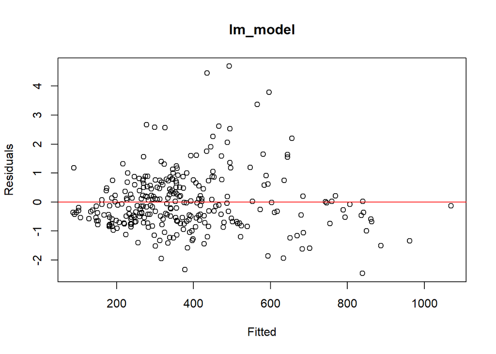

# Normality Plot

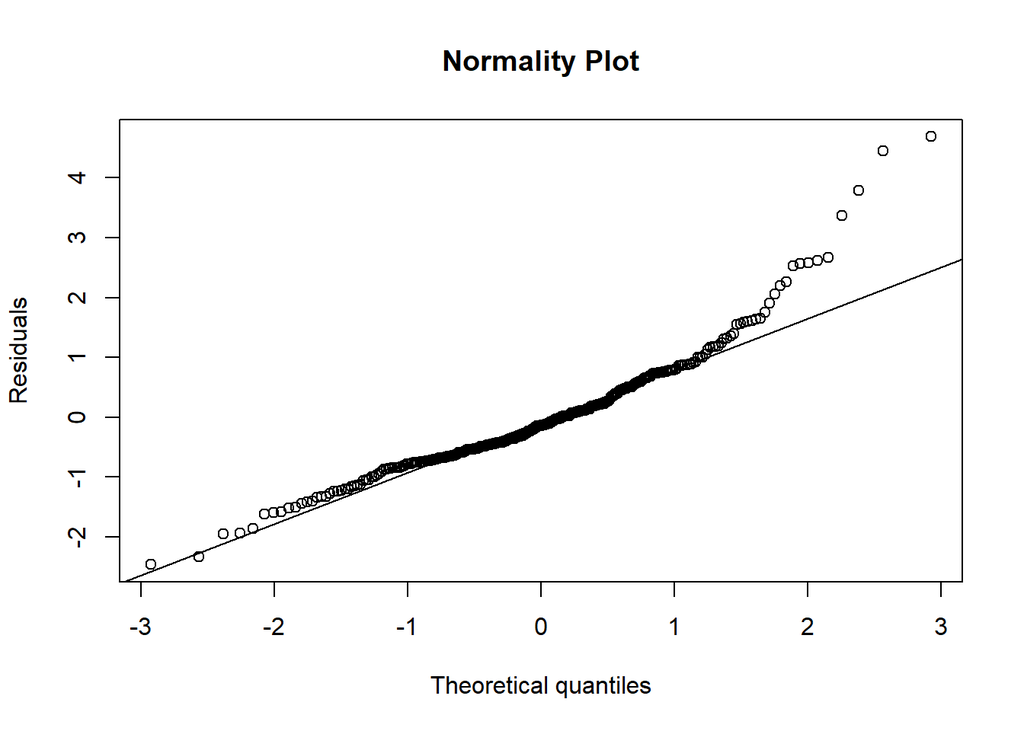

We start by testing the assumption of homoscedasticity (equal variances of residuals). The Breusch-Pagan test is commonly used for this purpose. The Breusch-Pagan test p-value:0.0001386791 If p-value is below a significance level (e.g., 0.05), the assumption of homoscedasticity is violated.

Next, we test the normality of residuals. The Shapiro-Wilk test can be used for this purpose. The Shapiro-Wilk test p-value: 0.0000000001676222 If p-value is below a significance level (e.g., 0.05), the assumption of normality is violated.

Omnibus Test: 77.318

Jarque-Bera Test: 205.740

Skew: 1.225 Kurtosis: 6.329 Prob(JB): 2.11e-45 Interpretation: The Jarque-Bera test checks for normality of residuals. A high test statistic (205.740) and a very low p-value (2.11e-45) indicate that the residuals may not be normally distributed. Additionally, skew (1.225) and kurtosis (6.329) values can suggest non-normality and potential outliers.

Condition Number: 7.04e+09

Interpretation: The condition number assesses multicollinearity in the model. A very high condition number (7.04e+09) may indicate a strong multicollinearity issue among predictor variables.

Zero Mean Errors:

Assumption: The errors have a mean value of zero. Confirmation: The mean of the errors is very close to zero suggesting that this assumption is met..

Independent Errors (Durbin-Watson Test):

Assumption: The errors are independent with no autocorrelation. Confirmation:The Durbin-Watson statistic is close to 2, indicating no significant autocorrelation.

Homoscedasticity (Constant Spread in Residuals):

Assumption: The spread of errors is consistent across different levels of predictor variables. Confirmation: This assumption is violated as there iss a non-constant spread in residuals as shown in the test and the plot.

Normality of Residuals (Jarque-Bera Test):

Assumption: The errors follow a normal distribution. Confirmation: The Jarque-Bera test results indicate non-normality of residuals as shown by the test and plot.

Multicollinearity (Condition Number):

Assumption: Predictor variables are not strongly correlated. Confirmation: A high condition number suggests strong multicollinearity

# References

1. R Core Team (2019). R: A language and environment for statistical computing. R Foundation for Statistical Computing, Vienna, Austria. URL https://www.R-project.org/.
2. Wickham et al. (2019). Welcome to the tidyverse. Journal of Open Source Software, 4(43), 1686, https://doi.org/10.21105/joss.01686.
3. Meyer, M. (2002). Uncounted Votes: Does Voting Equipment Matter? Chance Methods, 15(4), 33-38.
4. National Government Constituencies Development Fund (NGCDF) (2013-2017). Title of the Webpage. https://ngcdf.go.ke/allocations/. Retrieved October 23, 2023.
5. The Electoral Knowledge Network (2013). Title of the Webpage. https://aceproject.org/ero-en/regions/africa/KE/kenya-constituency-summary-of-voter-turnout-the. Retrieved October 2023.